# Week 02｜R 資料操作與科學研究七問題分析練習

本作業使用吸菸習慣調查 `openintro::smoking` 與汽車燃油效率 `ggplot2::mpg` 兩份資料。使用的 R 操作仍以本週 tutorial 為範圍。

請在自己的 `HT3001B_week02` Project 中完成。載入 `tidyverse` 與 `openintro` 後，可使用上述資料；先用 `?smoking`、`?mpg` 查閱資料說明。

| 題目 | 主要任務 |
| --- | --- |
| 第 1 題 | 依研究問題撰寫分析程式 |
| 第 2 題 | 撰寫程式重建範例圖與表，回答七問 |

兩題均須繳交程式、實際執行結果與文末的「科學研究七問題作答表」。第 1 題先依研究問題規劃分析；第 2 題先從圖表判讀，再提出與圖表相符的研究問題。七問請寫出目前最合理的答案；不知道時，寫明暫定判斷、依據與待確認資訊。

請儘量自力完成作答；若使用AI，請記錄提問的問題內容。

本次以資料整理、描述性統計與基本圖形為主，不要求假設檢定、p 值、信賴區間或迴歸模型。第 6 問可先用白話描述方法方向。

## 第 1 題｜吸菸者週末與平日的每日吸菸量有何差異？

**研究問題：**在 `smoking` 調查中，自陳有吸菸的受訪者，週末每天吸菸的支數平均比平日每天多多少？同一人的兩種每日吸菸量呈現什麼關係？

這份資料來自英國的吸菸習慣調查，每列代表一位受訪者。`smoke` 的 `Yes`、`No` 表示是否吸菸；`amt_weekends` 與 `amt_weekdays` 分別是週末及平日的**每日**吸菸支數，不是一整個週末或五個平日的總支數。

**請完成下列工作：**

1. 將 `smoking` 寫成 `data/smoking_practice.csv`，再讀入新物件。核對列數、欄位名稱及型態，後續使用讀回的資料分析。
2. 保留 `smoke == "Yes"` 的受訪者，選取需要的欄位，保存成新物件。原始資料的吸菸量欄位含有缺值；請查看篩選前後的資料，不可將缺值直接當成 0。提供的套件版本中，篩選後本題所用的兩個吸菸量欄位沒有缺值。
3. 新增 `weekend_minus_weekday`，定義為「週末每日支數減平日每日支數」。用程式計算受訪者人數、平日與週末各自的平均每日支數，以及平均支數差，整理成一張結果表。可將各段程式輸出整理成表，不要求尚未教過的製表函數。
4. 畫出橫軸為平日每日吸菸支數、縱軸為週末每日吸菸支數的散布圖，清楚標示座標軸與單位。
5. 說明平均差的正負方向，以及圖中呈現的關係。平均差能否代表每位受訪者的差異？這份調查能否證明「週末休假使人增加吸菸量」？說明理由。
6. 完成文末七問，特別交代兩個數值是否來自同一人，以及「比較平均差」和「觀察兩變項的關聯」各回答什麼問題。

**繳交：** `q1.R`、結果表、散布圖與七問答案。

## 第 2 題｜重建汽車驅動方式的圖與表

使用 `mpg` 的全部 234 筆紀錄。資料記錄車款在不同年份與規格下的燃油效率；一列是一筆車款／規格紀錄，不能直接當成一位車主或一輛追蹤中的實體汽車。

`drv` 的 `f` 表示前輪驅動，`r` 表示後輪驅動，`4` 表示四輪驅動。請建立 `drive_group`：`f` 與 `r` 合併為 `2WD`，`4` 歸為 `4WD`。`drv` 是文字欄位，判斷時應使用字串 `"4"`。

**範例圖**

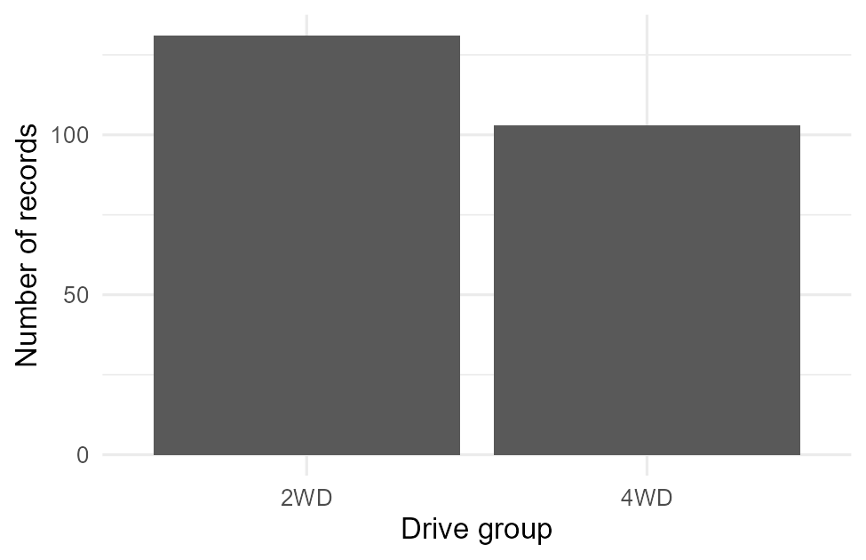

汽車驅動方式次數圖：2WD 有 131 筆，4WD 有 103 筆。

**範例表**

| drive_group | n |
| --- | --- |
| 2WD | 131 |
| 4WD | 103 |

**請完成下列工作：**

1. 從原始 `mpg` 撰寫程式，建立新欄位，再產生與範例相同的次數表及長條圖。次數須由資料計算，不可直接輸入範例數字，也不可把範例圖片當作輸出。
2. 確認兩類次數加總等於原始列數，並計算四輪驅動紀錄的比例，寫明分子與分母。
3. 用一句話提出圖表能回答的研究問題，再完成文末七問。這是單一比例的描述問題，第 3 問若沒有主要解釋變項，可以註明「本題未設定」，並說明理由。
4. 判斷這個比例能否解釋為「路上行駛的汽車有多少比例是四輪驅動」。請查閱 `?mpg` 的資料收錄方式，指出還需要哪些資訊。
5. 這張次數圖能否判斷「四輪驅動車的高速公路燃油效率比較低」？若不足，需要加入哪個欄位及什麼比較？本小題只須提出方向。

圖形須有正確的類別、長條高度及座標軸；不要求字型、顏色或背景完全相同。

**繳交：** `q2.R`、重建的圖與表、比例計算與七問答案。

## 兩題共用：Week 01 七問作答表

每題分別填寫一份。請先寫目前最合理的答案，再註明依據；教材、資料說明與實際輸出尚未提供的資訊，列為待確認，不以猜測補成事實。第 1 題先回答第 1–6 問，執行後完成第 7 問；第 2 題先讀圖表作答，再依重建結果修訂。

| Week 01 科學研究七問題 | 本次作答要點 |
| --- | --- |
| 1. 實質研究問題是什麼？ | 對象是誰？比較什麼或描述什麼關係？結果及時間為何？未提供測量時間時註明待確認。 |
| 2. 想估計或預測的量是什麼？ | 說明平均數差、比例或關係方向；適用時寫出相減方向、分母、時間與單位。 |
| 3. 結果變項與解釋變項是什麼？各屬於哪種資料型態？ | 列出欄位、角色與型態，區分識別欄位、分組欄位與結果變項的用途。 |
| 4. 觀察值如何產生、抽樣或分派？研究設計容許哪些推論？ | 查閱資料說明，區分抽樣與分派；指出目前可以推論的範圍與尚缺資訊。 |
| 5. 觀察值是否獨立、配對、重複測量或群聚？ | 說明一列代表什麼，哪些數值來自同一人，以及同一車款的紀錄可能有何關係；無法判定時寫出查核方式。 |
| 6. 哪類方法符合問題與資料結構？主要假設是什麼？ | 先寫本次採用的描述方法與圖形，再列出至少兩項資料或分析前提的檢查。進階方法可標示待學習。 |
| 7. 結果能支持什麼結論？不能說什麼？ | 根據實際輸出回答研究問題，列出至少一項不能支持的結論及理由。分析前可寫「預計報告……」，分析後須改用真實結果。 |

每問以 2–4 句為原則；可使用「目前判斷：……；依據：……；待確認：……」的格式。清楚指出資訊缺口也是有效答案。

## 繳交前確認

- 各題程式包含必要的套件載入與資料準備；重新啟動 R 後能從頭執行，不依賴前一題留在 Environment 的物件。
- 提交 `.R` 程式、圖表與文字答案，不能只交截圖。圖可由 Plots 面板匯出，不要求使用新的匯出函數。
- 圖表數值須由程式計算而非手算。
- 若使用AI請記錄提問的問題內容。